# Homework7 _ TengSiongYeap

TengSiong (T.S) YEAP

March 2, 2019

```r
library(ggplot2)
dim(diamonds)
```

```
## [1] 53940    10
```

```r
str(diamonds)
```

```
## Classes 'tbl_df', 'tbl' and 'data.frame':    53940 obs. of  10 variables:
##  $ carat  : num  0.23 0.21 0.23 0.29 0.31 0.24 0.24 0.26 0.22 0.23 ...
##  $ cut    : Ord.factor w/ 5 levels "Fair"<"Good"<..: 5 4 2 4 2 3 3 3 1 3 ...
##  $ color  : Ord.factor w/ 7 levels "D"<"E"<"F"<"G"<..: 2 2 2 6 7 7 6 5 2 5 ...
##  $ clarity: Ord.factor w/ 8 levels "I1"<"SI2"<"SI1"<..: 2 3 5 4 2 6 7 3 4 5 ...
##  $ depth  : num  61.5 59.8 56.9 62.4 63.3 62.8 62.3 61.9 65.1 59.4 ...
##  $ table  : num  55 61 65 58 58 57 57 55 61 61 ...
##  $ price  : int  326 326 327 334 335 336 336 337 337 338 ...
##  $ x      : num  3.95 3.89 4.05 4.2 4.34 3.94 3.95 4.07 3.87 4 ...
##  $ y      : num  3.98 3.84 4.07 4.23 4.35 3.96 3.98 4.11 3.78 4.05 ...
##  $ z      : num  2.43 2.31 2.31 2.63 2.75 2.48 2.47 2.53 2.49 2.39 ...
```

```r
#Check the level of clarity
print(levels(diamonds$clarity))
```

```
## [1] "I1"   "SI2"  "SI1"  "VS2"  "VS1"  "VVS2" "VVS1" "IF"
```

```r
#According to ?diamonds, the order should be: (I1 (worst), SI2, SI1, VS2, VS1, VVS2, VVS1, IF (best)), which is different than what is being stated in the assignment as well

#Re-arrange the order from the worst to the best
diamonds$clarity <- factor(diamonds$clarity,
                            labels = c("I1", "SI2", "SI1", "VS2", "VS1", "VVS2",
                                       "VVS1", "IF"))
```

**1. Recreate the above boxplot using ggplot. What does this tell you about median price with respect to clarity?**

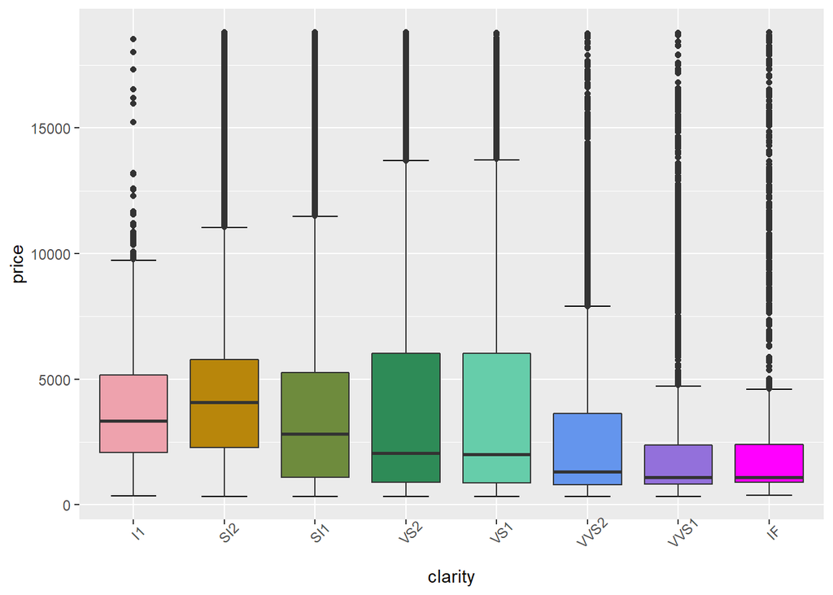

```r
rainbow = c("lightpink2","darkgoldenrod","darkolivegreen4","seagreen",
            "mediumaquamarine","cornflowerblue","mediumpurple","magenta1")
p1 <- ggplot(data = diamonds, aes(x = clarity, y = price, fill = clarity)) +

      #to add the perpendicular line at the end of whiskers
      stat_boxplot(geom ='errorbar', width = 0.5) +
      geom_boxplot() +
      scale_x_discrete(name = "clarity") +
      scale_y_continuous(name = "price") +
      theme(axis.text.x = element_text(angle = 45), legend.position="none") +
      scale_fill_manual(values= rainbow)
p1
```

**2. Recreate the above boxplot to show caret by clarity. What does this tell you about caret size with respect to clarity**

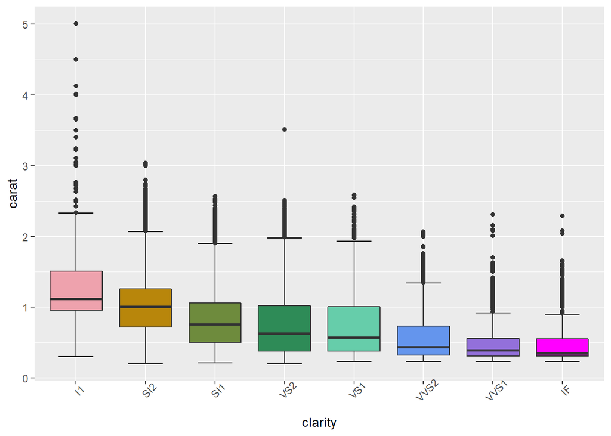

```r
p2 <- ggplot(data = diamonds, aes(x = clarity, y = carat, fill = clarity)) +

      #to add the perpendicular line at the end of whiskers
      stat_boxplot(geom ='errorbar', width = 0.5) +
      geom_boxplot() +
      scale_x_discrete(name = "clarity") +
      scale_y_continuous(name = "carat") +
      theme(axis.text.x = element_text(angle = 45), legend.position="none") +
      scale_fill_manual(values= rainbow)
p2
```

*The distribution of the size of carat is getting smaller from the worst clarty to the best clarity*

**3. Recreate the above stacked bar chart using ggplot, What does the stacked bar say about clarity and color. Do lower clarity diamonds have good color and why. Is there an association between clarity and color, why**

```r
#Check the level of color
print(levels(diamonds$color))
```

```
## [1] "D" "E" "F" "G" "H" "I" "J"
```

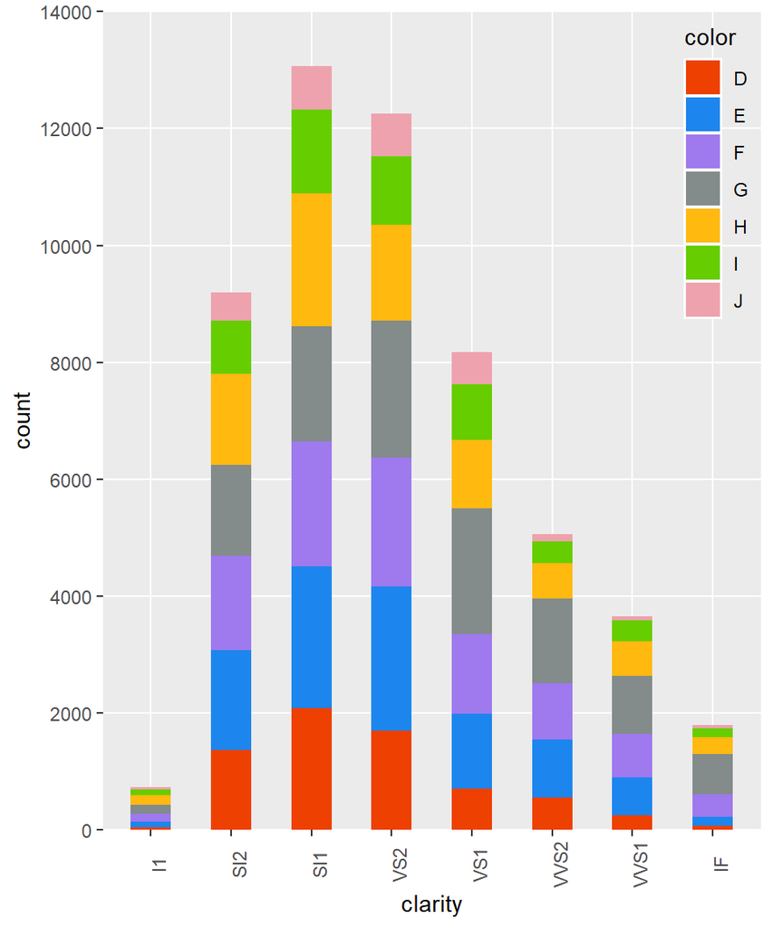

```r
#set color for each level
p3color <- c("D" = "orangered2",
             "E" = "dodgerblue2",
             "F" = "mediumpurple2",
             "G" = "azure4",
             "H" = "darkgoldenrod1",
             "I" = "chartreuse3",
             "J" = "lightpink2")

p3 <- ggplot(data = diamonds) +
      geom_bar(aes(x = clarity,
                   fill = forcats::fct_rev(color)), #reversed the stacked bar
                   width = 0.5) +
      scale_y_continuous(breaks = seq(0,14000,2000),
                         limits = c(0,14001),
                         expand = c(0, 0)) + #plot stops at the end of y-tick
      theme(axis.text.x = element_text(angle = 90),
            panel.grid.minor = element_blank(), #remove minor grid
            legend.position = c(1, 1), #include legend inside the plot
            legend.justification = c("right", "top"), #top right position
            legend.box.just = "right",
            legend.background = element_blank(), #remove the background of the legend
            legend.margin = margin(6, 6, 6, 6)) +
      scale_fill_manual(values = p3color,
                        name = "color",  #rename the legend
                        guide = guide_legend(reverse=TRUE)) #reverse the order
p3
```

*The stacked bar is in the bell shape distribution. The extreme ends of the distribution do not have many good color. However, the below average clarity diamonds have more good color than the diamonds that are above average in clarity. It is because it is very rare to have a clearer diamond with good color.*